# 01 Data preparation

Author

Dybcio Katarzyna, Frejter Quoc

Published

May 4, 2024

```r
packages <- c("readr","xts","tidyverse")

for (package in packages) {
  if (!require(package, character.only = TRUE)) {
    install.packages(package)
    library(package, character.only = TRUE)
  }
}
```

# 1 Loading data

Financial Instruments S&P 500, NVDA and EUR/USD were loaded from stooq.pl. Cocoa futures was loaded from yahoo.com, XRP from coinmarketcap.com. Our observarions starts 2019-01-01 and ends on 2024-01-01

```r
library(readr)
sp500 <- read_csv("data/^spx_d.csv", col_types = cols(Data = col_date(format = "%Y-%m-%d")))
SP_prices <- as.xts(sp500$Zamkniecie,order.by = sp500$Data)

eur_usd <- read_csv("data/eurusd_d.csv", col_types = cols(Data = col_date(format = "%Y-%m-%d")))
EURUSD_prices <- as.xts(eur_usd$Zamkniecie,order.by = eur_usd$Data)

nvda <- read_csv("data/nvda_us_d.csv", col_types = cols(Data = col_date(format = "%Y-%m-%d")))
NVDA_prices <- as.xts(nvda$Zamkniecie,order.by = nvda$Data)

cc <- read_csv("data/CC=F.csv", col_types = cols(Date = col_date()))
CC_prices <- as.xts(cc["Adj Close"],order.by = cc$Date)
names(CC_prices) <- "CC_prices"

xrp <- read_csv("data/xrp_v_d.csv", col_types = cols(Data = col_date(format = "%Y-%m-%d")))
XRP_prices <- as.xts(xrp$Zamkniecie,order.by = xrp$Data)

merged <- cbind(SP_prices,EURUSD_prices,NVDA_prices,CC_prices,XRP_prices)
```

# 2 Data investigation

```r
head(merged)
```

```
           SP_prices EURUSD_prices NVDA_prices CC_prices XRP_prices
2019-01-01        NA            NA          NA        NA     0.3650
2019-01-02   2510.03       1.13426     33.7886      2394     0.3833
2019-01-03   2447.89       1.13940     31.7462      2400     0.3624
2019-01-04   2531.94       1.14029     33.7817      2361     0.3622
2019-01-05        NA            NA          NA        NA     0.3596
2019-01-06        NA            NA          NA        NA     0.3704
```

```r
tail(merged)
```

```
           SP_prices EURUSD_prices NVDA_prices CC_prices XRP_prices
2023-12-27   4781.58       1.11060     494.147      4280   0.632792
2023-12-28   4783.35       1.10623     495.197      4256   0.633872
2023-12-29   4769.83       1.10410     495.197      4196   0.619624
2023-12-30        NA            NA          NA        NA   0.621181
2023-12-31        NA            NA          NA        NA   0.611347
2024-01-01        NA            NA          NA        NA   0.627019
```

```r
merged |> summary()
```

```
     Index              SP_prices    EURUSD_prices     NVDA_prices
 Min.   :2019-01-01   Min.   :2237   Min.   :0.9596   Min.   : 31.75
 1st Qu.:2020-04-01   1st Qu.:3129   1st Qu.:1.0821   1st Qu.: 68.07
 Median :2021-07-01   Median :3907   Median :1.1132   Median :145.54
 Mean   :2021-07-01   Mean   :3756   Mean   :1.1158   Mean   :177.23
 3rd Qu.:2022-09-30   3rd Qu.:4305   3rd Qu.:1.1594   3rd Qu.:230.64
 Max.   :2024-01-01   Max.   :4797   Max.   :1.2328   Max.   :504.02
                      NA's   :567    NA's   :533      NA's   :567
   CC_prices      XRP_prices
 Min.   :2111   Min.   :0.1383
 1st Qu.:2380   1st Qu.:0.2922
 Median :2497   Median :0.3996
 Mean   :2633   Mean   :0.4923
 3rd Qu.:2677   3rd Qu.:0.6140
 Max.   :4475   Max.   :1.8140
 NA's   :566    NA's   :1
```

# 3 Missing data

We can notice that on holidays only XRP - cryptocurrency is quoted/traded, but the rest is not. We could assume that we will have missing values for bank holidays (NVDA and SP500 US bank holidays). In such cases there is no change in price. Filling NANs with previous observations might affect our index by artificially lowering our volatility. We decided not to model those days, our analysis will be performed only on actual trading days.

```r
merged <- na.omit(merged)
merged |> summary()
```

```
     Index              SP_prices    EURUSD_prices     NVDA_prices
 Min.   :2019-01-02   Min.   :2237   Min.   :0.9596   Min.   : 31.75
 1st Qu.:2020-04-01   1st Qu.:3128   1st Qu.:1.0823   1st Qu.: 68.05
 Median :2021-06-30   Median :3907   Median :1.1133   Median :145.25
 Mean   :2021-06-30   Mean   :3756   Mean   :1.1160   Mean   :177.24
 3rd Qu.:2022-09-28   3rd Qu.:4305   3rd Qu.:1.1597   3rd Qu.:230.90
 Max.   :2023-12-29   Max.   :4797   Max.   :1.2328   Max.   :504.02
   CC_prices      XRP_prices
 Min.   :2111   Min.   :0.1383
 1st Qu.:2379   1st Qu.:0.2932
 Median :2497   Median :0.3996
 Mean   :2632   Mean   :0.4930
 3rd Qu.:2677   3rd Qu.:0.6160
 Max.   :4475   Max.   :1.8140
```

# 4 Returns

```r
# Simple net returns

merged$SP_SimReturns <- (merged$SP_prices/lag(merged$SP_prices)) - 1
merged$NVDA_SimReturns <- (merged$NVDA_prices/lag(merged$NVDA_prices)) - 1
merged$EURUSD_SimReturns <- (merged$EURUSD_prices/lag(merged$EURUSD_prices)) - 1
merged$CC_SimReturns <- (merged$CC_prices/lag(merged$CC_prices)) -1
merged$XRP_SimReturns <- (merged$XRP_prices/lag(merged$XRP_prices)) - 1

# Log returns

merged$SP_LnReturns <- log(merged$SP_prices/lag(merged$SP_prices))
merged$NVDA_LnReturns <- log(merged$NVDA_prices/lag(merged$NVDA_prices))
merged$EURUSD_LnReturns <- log(merged$EURUSD_prices/lag(merged$EURUSD_prices))
merged$CC_LnReturns <- log(merged$CC_prices/lag(merged$CC_prices))
merged$XRP_LnReturns <- log(merged$XRP_prices/lag(merged$XRP_prices))

merged$SP_LnReturns[1] <- 0
merged$NVDA_LnReturns[1] <- 0
merged$EURUSD_LnReturns[1] <- 0
merged$CC_LnReturns[1] <- 0
merged$XRP_LnReturns[1] <- 0

# Cumulative returns

merged$SP_CumReturns <- exp(cumsum(merged$SP_LnReturns)) - 1
merged$NVDA_CumReturns <- exp(cumsum(merged$NVDA_LnReturns))  - 1
merged$CC_CumReturns <- exp(cumsum(merged$CC_LnReturns))  - 1
merged$EURUSD_CumReturns <- exp(cumsum(merged$EURUSD_LnReturns))  - 1
merged$XRP_CumReturns <- exp(cumsum(merged$XRP_LnReturns))  - 1
```

# 5 Index creation

Index returns are sum of equally weighted components returns

S - SP500 N - NVDA E - EUR U - USD C - COCOA X - XRP

- Simple Net return was calculated as equally weighted average of net simple return of five underlying instruments.
- Gross Return was calculated as Simple Net Return +1.
- Value of the Index is equal to the Cumulative Product of Gross Return
- Log return is equal to the logarithm of value of the index in time t divided by lagged value of this index.

```r
SNEUCX_index <-xts(order.by = index(merged))

SNEUCX_index$index_SimReturns = (merged$SP_SimReturns + merged$NVDA_SimReturns +
                                  merged$EURUSD_SimReturns + merged$CC_SimReturns +
                                  merged$XRP_SimReturns)/5

SNEUCX_index$index_SimReturns["2019-01-02"] <- 0

SNEUCX_index$index_Sim_Gross_Returns <- SNEUCX_index$index_SimReturns + 1

SNEUCX_index$CumRet <- cumprod(SNEUCX_index$index_Sim_Gross_Returns) - 1

SNEUCX_index$LnReturns <- log(SNEUCX_index$index_Sim_Gross_Returns)
SNEUCX_index$LnReturns[1] <- 0
```

# 6 Plots

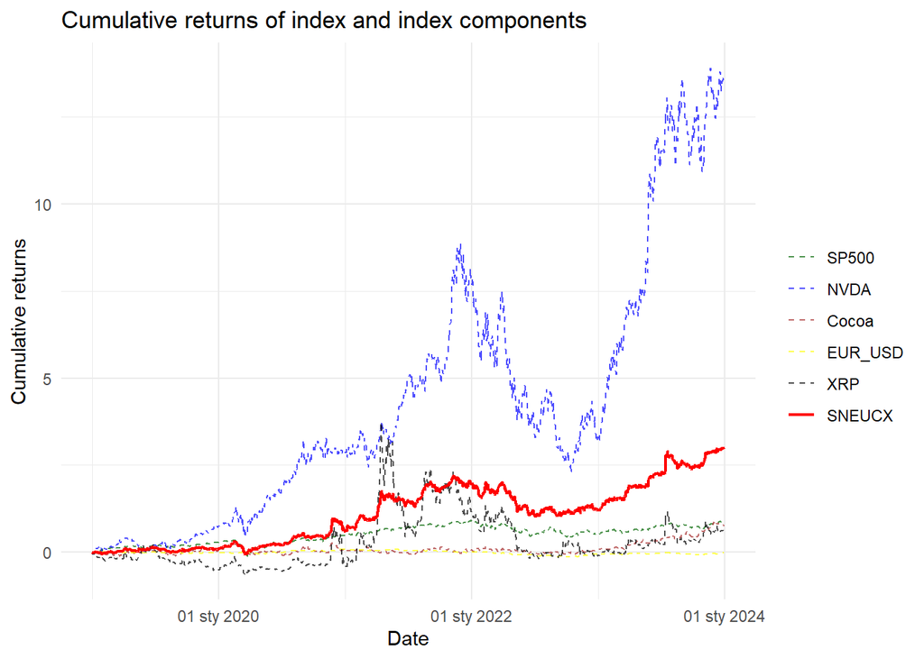

```r
ggplot() +
  geom_line(aes(x = index(merged),
                y = merged$SP_CumReturns, color = "SP500"),
            alpha = 0.7, linetype="dashed") +
  geom_line(aes(x = index(merged),
                y = merged$NVDA_CumReturns, color = "NVDA"),
            alpha = 0.7, linetype="dashed") +
  geom_line(aes(x = index(merged),
                y = merged$CC_CumReturns, color = "Cocoa"),
            alpha = 0.7, linetype="dashed") +
  geom_line(aes(x = index(merged),
                y = merged$EURUSD_CumReturns, color = "EUR_USD"),
            alpha = 0.7, linetype="dashed") +
  geom_line(aes(x = index(merged),
                y = merged$XRP_CumReturns, color = "XRP"),
            alpha = 0.7, linetype="dashed") +
  geom_line(aes(x = index(SNEUCX_index),
                y = SNEUCX_index$CumRet, color = "SNEUCX"),
            linewidth = 0.8) +
  xlab("Date") +
  ylab("Cumulative returns") +
  ggtitle('Cumulative returns of index and index components') +
  scale_x_date(date_labels = "%d %b %Y") +
  theme_minimal() +
  scale_color_manual(name='',
                     breaks = c('SP500','NVDA','Cocoa',
                                'EUR_USD', 'XRP', 'SNEUCX'),
                     values = c('SP500'='darkgreen','NVDA'='blue',
                                'Cocoa' = 'brown', 'EUR_USD' = 'yellow',
                                'XRP' = 'black', 'SNEUCX' = 'red')
                     )
```

# 7 Save index data

```r
# Train data

saveRDS(SNEUCX_index["2019-01-01/2022-12-31",c("CumRet","LnReturns")],
        file = "input/SNEUCX_train.rds")

# Test data

saveRDS(SNEUCX_index["2023-01-01/2023-12-31",c("CumRet","LnReturns")],
        file = "input/SNEUCX_test.rds")
```